```
GitHub repo:
https://github.com/expfactory-experiments/stroop-5min

Pre-registration (approved July 24, 2018):
https://osf.io/9pc46/

Live demo version:
https://expfactory-experiments.github.io/stroop-5min
```

Tyler Burleigh, PhD[^1] [Vanessa Sochat, PhD](https://vsoch.github.io)[^2]

July 28, 2018

Abstract

This report demonstrates the preliminary validity and user acceptance of a 5-minute web-based Stroop task. This task was created out of a need for a more brief and user-friendly version of the Stroop task than was provided in the `expfactory` library (Eisenberg et al., 2018; Sochat et al., 2016). In comparison to the original `expfactory` Stroop, this version is 39% shorter (5.0 vs. 8.2 minutes). Notably, this reduction in length did not reduce the size of the Stroop effect that was obtained. Thus, the 5 Minute Stroop appears to be a reasonable short-form substitute.

```r
library(knitr)
library(dplyr)
library(ggplot2)
library(effsize)
library(Rmisc)
library(ggthemr)
library(gmodels)
library(TOSTER)
library(lsr)
ggthemr('dust')
```

# Changelog

```
- Practice trials reduced from 24 to 18
- Test trials reduced from 96 to 72
- Ratio of congruent:incongruent trials increased from 1:1 to 2:1
- Self-paced (trial ends immediately on response)
- Colors selected to be color-blind safe (http://colororacle.org)
- Color words in bolder font
- Instructions improved with finger placement diagram
- Background color changed to black to minimize eye strain
- Various small improvements to instructions and feedback
- Attention check added
```

# Data and analysis

We recruited 50 participants from MTurk, of which 3 failed the attention check and were therefore not included in the performance analysis. Data collected with the original `expfactory` Stroop task (n = 277) is freely available and was included in the performance analyses as a baseline (Eisenberg et al., 2018).[^1]

## Stroop effect (milliseconds)

The Stroop effect is typically measured as the difference in response times between incongruent and congruent stimuli. Because incongruent stimuli create "interference" while congruent stimuli create response "facilitation," individuals are slower to respond to incongruent (vs. congruent) stimuli. Our measure of the Stroop effect is the within-subjects mean difference in response times between incongruent and congruent stimuli, where a higher value corresponds with a larger Stroop effect. We can see that the Stroop effect was as large in the 5 Minute Stroop as it was in the Original Stroop. (With fewer data points the confidence interval was wider, but this is to be expected.)

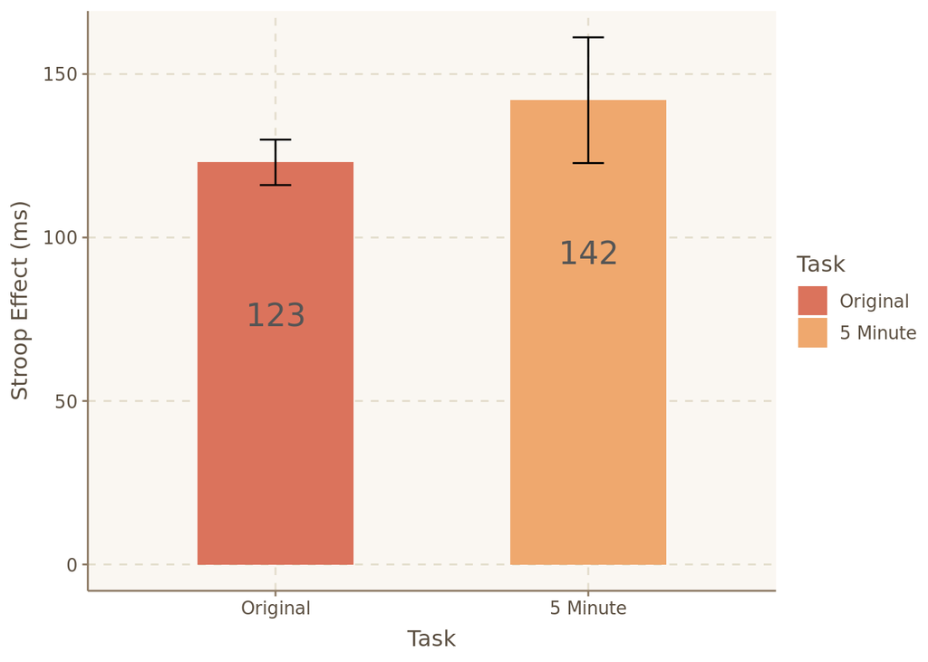

```r
load("/home/rstudio/usr/MTurk/Stroop/m_ref.R")
load("/home/rstudio/usr/MTurk/Stroop/m.R")

table <- data.frame(matrix(c(
            "Original",
            round(mean(m_ref$RT_incong) - mean(m_ref$RT_cong)),
            ci(m_ref$RT_incong - m_ref$RT_cong)[[1]] - ci(m_ref$RT_incong - m_ref$RT_cong)[[2]],

            "5 Minute",
            round(mean(m$RT_incong) - mean(m$RT_cong)),
            ci(m$RT_incong - m$RT_cong)[[1]] - ci(m$RT_incong - m$RT_cong)[[2]]

            ),ncol=3, byrow=TRUE), stringsAsFactors=FALSE)

colnames(table) <- c("Task", "Mean", "CI")
table[,2] <- as.numeric(table[,2])
table[,3] <- as.numeric(table[,3])
table$Task <- factor(table$Task, levels = c("Original", "5 Minute"))

ggplot(table, aes(x=Task, y=Mean, fill=Task)) +
    geom_bar(position=position_dodge(), stat="identity", width=0.5) +
    geom_errorbar(aes(ymin=as.numeric(Mean-CI), ymax=as.numeric(Mean+CI)),
                  width=.1, color="black",
                  position=position_dodge(.9)) + ylab("Stroop Effect (ms)") +
    geom_text(aes(x = Task, y = Mean, label = Mean, group = Task),
              position = position_dodge(width = 1),
              vjust = 7, size = 6
            )
```

## Stroop effect (Cohen’s d)

We can also measure the Stroop effect in terms of the magnitude of its effect size. Cohen's d effect sizes are often interpreted with the following rule of thumb: d = 0.2 is a "small" effect, d = 0.5 is a "medium" effect, and d = 0.8 or greater is a "large" effect. As with the millisecond measure of the effect, we also see similar effect sizes as measured by Cohen's d between the two tasks, and for both tasks the effect was large.

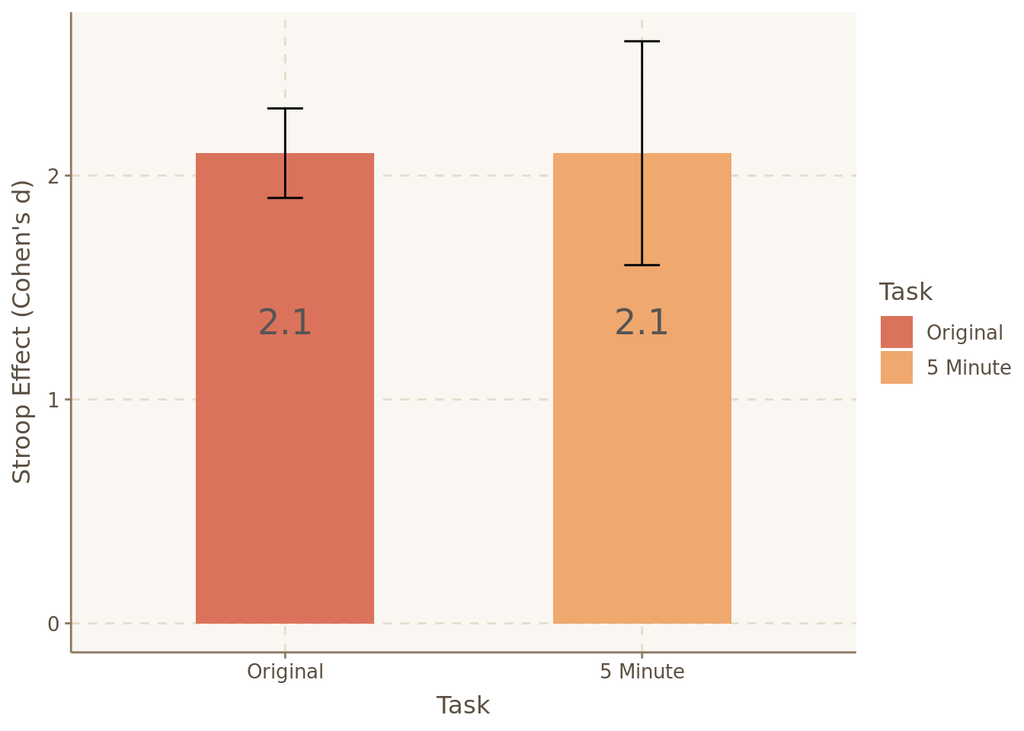

```r
table <- data.frame(matrix(c(
            "Original",
            round(cohen.d(m_ref$RT_incong, m_ref$RT_cong, paired=TRUE)[[3]],2),
            round(cohen.d(m_ref$RT_incong, m_ref$RT_cong, paired=TRUE)[[3]],1)-round(cohen.d(m_ref$RT_incong, m_ref$RT_cong, paired=TRUE)[[4]][[1]],1),

            "5 Minute",
            round(cohen.d(m$RT_incong, m$RT_cong, paired=TRUE)[[3]],2),
            round(cohen.d(m$RT_incong, m$RT_cong, paired=TRUE)[[3]],1)-round(cohen.d(m$RT_incong, m$RT_cong, paired=TRUE)[[4]][[1]],1)
            ),ncol=3, byrow=TRUE), stringsAsFactors=FALSE)

colnames(table) <- c("Task", "Mean", "CI")
table[,2] <- as.numeric(table[,2])
table[,3] <- as.numeric(table[,3])
table$Task <- factor(table$Task, levels = c("Original", "5 Minute"))

ggplot(table, aes(x=Task, y=Mean, fill=Task)) +
    geom_bar(position=position_dodge(), stat="identity", width=0.5) +
    geom_errorbar(aes(ymin=as.numeric(Mean-CI), ymax=as.numeric(Mean+CI)),
                  width=.1, color="black",
                  position=position_dodge(.9)) + ylab("Stroop Effect (Cohen's d)") +
    geom_text(aes(x = Task, y = Mean, label = Mean, group = Task),
              position = position_dodge(width = 1),
              vjust = 7, size = 6
            )
```

## Accuracy

Speeded-response tasks like the Stroop will often examine response times as well as accuracy. When examining accuracy, the logic is similar to response times: Because incongruent stimuli create response interference, activating an incorrect response to a greater degree than a congruent stimulus, there is a greater chance that participants will respond incorrectly to incongruent stimuli. For this reason, we would expect a greater proportion of incorrect responses for incongruent (vs. congruent) stimuli. We see this in the graphs below, and we also see that performance was similar between the two Stroop task versions.

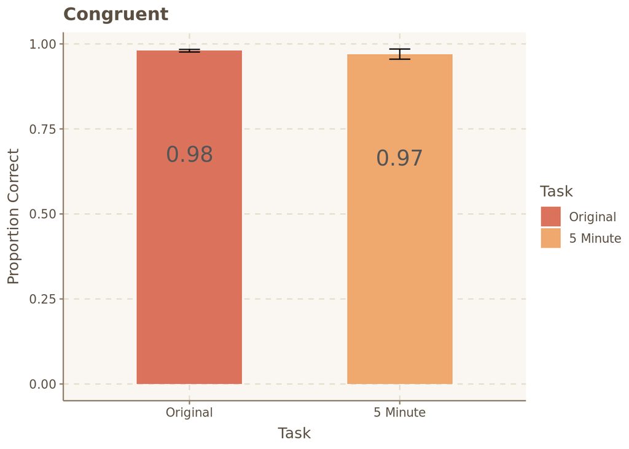

```r
table <- data.frame(matrix(c(
            "Original",
            round(mean(m_ref$Acc_cong),2),
            ci(m_ref$Acc_cong)[[1]] - ci(m_ref$Acc_cong)[[2]],

            "5 Minute",
            round(mean(m$Acc_cong),2),
            ci(m$Acc_cong)[[1]] - ci(m$Acc_cong)[[2]]

            ),ncol=3, byrow=TRUE), stringsAsFactors=FALSE)

colnames(table) <- c("Task", "Mean", "CI")
table[,2] <- as.numeric(table[,2])
table[,3] <- as.numeric(table[,3])
table$Task <- factor(table$Task, levels = c("Original", "5 Minute"))

plot1 <- ggplot(table, aes(x=Task, y=Mean, fill=Task)) +
    geom_bar(position=position_dodge(), stat="identity", width=0.5) +
    geom_errorbar(aes(ymin=as.numeric(Mean-CI), ymax=as.numeric(Mean+CI)),
                  width=.1, color="black",
                  position=position_dodge(.9)) + ylab("Proportion Correct") +
    geom_text(aes(x = Task, y = Mean, label = Mean, group = Task),
              position = position_dodge(width = 1),
              vjust = 7, size = 6
            ) + ggtitle("Congruent")


table <- data.frame(matrix(c(
            "Original",
            round(mean(m_ref$Acc_incong),2),
            ci(m_ref$Acc_incong)[[1]] - ci(m_ref$Acc_incong)[[2]],

            "5 Minute",
            round(mean(m$Acc_incong),2),
            ci(m$Acc_incong)[[1]] - ci(m$Acc_incong)[[2]]

            ),ncol=3, byrow=TRUE), stringsAsFactors=FALSE)

colnames(table) <- c("Task", "Mean", "CI")
table[,2] <- as.numeric(table[,2])
table[,3] <- as.numeric(table[,3])
table$Task <- factor(table$Task, levels = c("Original", "5 Minute"))

plot2 <- ggplot(table, aes(x=Task, y=Mean, fill=Task)) +
    geom_bar(position=position_dodge(), stat="identity", width=0.5) +
    geom_errorbar(aes(ymin=as.numeric(Mean-CI), ymax=as.numeric(Mean+CI)),
                  width=.1, color="black",
                  position=position_dodge(.9)) + ylab("Proportion Correct") +
    geom_text(aes(x = Task, y = Mean, label = Mean, group = Task),
              position = position_dodge(width = 1),
              vjust = 7, size = 6
            ) + ggtitle("Incongruent")


plot1
```

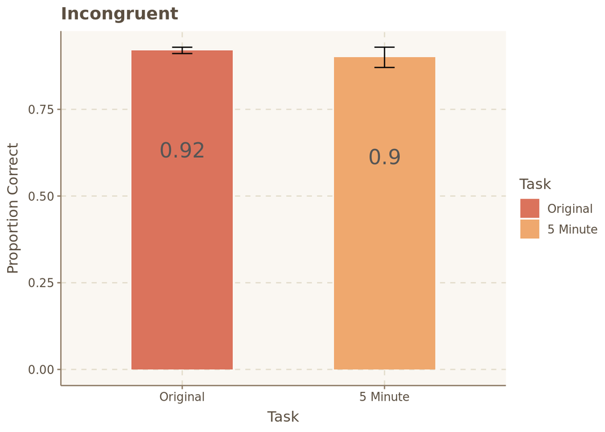

```r
plot2
```

## Completion time

My intention was to create a task that would only take 5 minutes to complete. So how long does it really take? We'll look at the completion times, which includes time spent reading the instructions as well as time spent on the experimental trials. The Original `expfactory` Stroop task took an average of 8.2 minutes to complete, while completion times averaged 5 minutes for the 5-minute Stroop. This is right on the mark, and it represents a time savings of 39%.

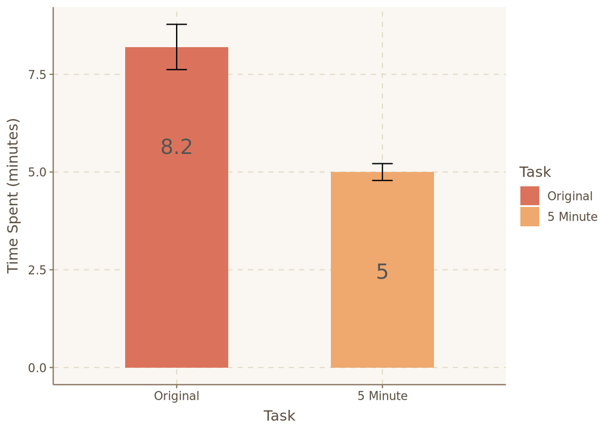

```r
table <- data.frame(matrix(c(
            "Original",
            round(mean(m_ref$TimeSpent)/60,1),
            ci(m_ref$TimeSpent/60)[[1]] - ci(m_ref$TimeSpent/60)[[2]],

            "5 Minute",
            round(mean(m$TimeSpent)/60,1),
            ci(m$TimeSpent/60)[[1]] - ci(m$TimeSpent/60)[[2]]

            ),ncol=3, byrow=TRUE), stringsAsFactors=FALSE)

colnames(table) <- c("Task", "Mean", "CI")
table[,2] <- as.numeric(table[,2])
table[,3] <- as.numeric(table[,3])
table$Task <- factor(table$Task, levels = c("Original", "5 Minute"))

ggplot(table, aes(x=Task, y=Mean, fill=Task)) +
    geom_bar(position=position_dodge(), stat="identity", width=0.5) +
    geom_errorbar(aes(ymin=as.numeric(Mean-CI), ymax=as.numeric(Mean+CI)),
                  width=.1, color="black",
                  position=position_dodge(.9)) + ylab("Time Spent (minutes)") +
    geom_text(aes(x = Task, y = Mean, label = Mean, group = Task),
              position = position_dodge(width = 1),
              vjust = 7, size = 6
            )
```

To really nail down the claim that the 5-Minute Stroop only takes 5 minutes, we can perform a Two One-Sided T-tests (TOST) procedure.[^2] Our hypothesis is that the completion time for this task is no different than 5 minutes, which is a null hypothesis. For that reason, we can't rely on the logic of null hypothesis testing alone (because null hypothesis testing seeks to reject a null hypothesis, and a null hypothesis cannot be confirmed with significance testing). Instead, the TOST procedure allows us to perform equivalence testing which is more robust in cases like this. We'll set the equivalence bounds to 0.5 minutes on either side of 5 minutes, such that if the task takes more than 5.5 minutes or less than 4.5 minutes (with a certain degree of confidence), then we will reject our claim that the task only takes 5 minutes to complete. Indeed, we can see from the TOST test that the average completion time was equivalent to 5 minutes.

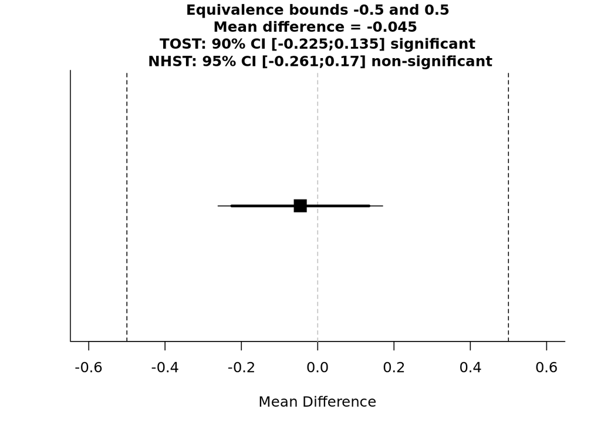

```
## Using alpha = 0.05 the NHST one-sample t-test was non-significant, t(49) = -0.4222776, p = 0.6746696
## Using alpha = 0.05 the equivalence test was significant, t(49) = 4.235196, p = 5.008621e-05TOST results:
##   t-value 1    p-value 1 t-value 2    p-value 2 df
## 1  4.235196 5.008621e-05 -5.079752 2.940681e-06 49
##
## Equivalence bounds (raw scores):
##   low bound raw high bound raw
## 1          -0.5            0.5
##
## TOST confidence interval:
##   Lower Limit 90% CI raw Upper Limit 90% CI raw
## 1             -0.2253183              0.1346517
```

```r
mt <- mean(m$TimeSpent/60)
sd_mt <- sd(m$TimeSpent/60)
n_mt <- length(m$TimeSpent)
TOSTone.raw(m = mt, mu = 5, sd = sd_mt, n = n_mt, low_eqbound = -0.5, high_eqbound = 0.5, alpha = 0.05, plot = TRUE)
```

## User acceptability

```r
# Read in csv data
qdf <- read.csv("/home/rstudio/usr/MTurk/Stroop/Demographics_Usability.csv")

# Drop first two rows because they're Qualtrics junk
qdf <- qdf[-c(1:2),]

# Code factors
qdf$Q2 <- factor(qdf$Q2, levels = c("Strongly disagree","Disagree","Neither agree nor disagree","Agree","Strongly agree"))
qdf$Q3 <- factor(qdf$Q3, levels = c("Strongly disagree","Disagree","Neither agree nor disagree","Agree","Strongly agree"))
qdf$Q4 <- factor(qdf$Q4, levels = c("Strongly disagree","Disagree","Neither agree nor disagree","Agree","Strongly agree"))
qdf$Q5 <- factor(qdf$Q5, levels = c("Strongly disagree","Disagree","Neither agree nor disagree","Agree","Strongly agree"))

# Compute Acceptability Score
qdf$Accept <- (as.numeric(qdf$Q2) + as.numeric(qdf$Q3) + as.numeric(qdf$Q4) + as.numeric(qdf$Q5))/4
```

```r
# t-test (test if greater than score of 3)
t.test(qdf$Accept, mu = 3, alternative="greater")
```

```
##
##  One Sample t-test
##
## data:  qdf$Accept
## t = 12.899, df = 48, p-value < 2.2e-16
## alternative hypothesis: true mean is greater than 3
## 95 percent confidence interval:
##  3.945432      Inf
## sample estimates:
## mean of x
##  4.086735
```

```r
# Effect size
print(paste("Cohen's d =", round(cohensD(qdf$Accept, mu = 3),2)))
```

```
## [1] "Cohen's d = 1.84"
```

## Final notes

Data from this study is available at the OSF project site (https://osf.io/9pc46).

## Cite as

Burleigh, T, & Sochat, V. (2018, July 28). Preliminary Validation and Usability of a 5-Minute Web Stroop (Mini Report). Zenodo. http://doi.org/10.5281/zenodo.1323329

# References

Eisenberg, I. W., Bissett, P., Enkavi, A. Z., Li, J., MacKinnon, D., Marsch, L., & Poldrack, R. (2018, July 23). Uncovering mental structure through data-driven ontology discovery. https://doi.org/10.31234/osf.io/fvqej

Sochat, V. V., Eisenberg, I. W., Enkavi, A. Z., Li, J., Bissett, P. G., & Poldrack, R. A. (2016). The Experiment Factory: Standardizing Behavioral Experiments. Frontiers in Psychology, 7(610). https://10.3389/fpsyg.2016.00610

[^1]: https://github.com/IanEisenberg/Self_Regulation_Ontology/tree/master/Data/Complete_03-29-2018
[^2]: http://daniellakens.blogspot.com/